# Homework

## Arrays

You are given a multi-dimensional array `array.rds`. It contains penetrance curves for various cancers and genes. In simple terms, penetrances are how likely one will develop a cancer given that they have a certain corresponding gene mutation. Other variables in `data` describe different sub-populations. For example, the probabilities corresponding to `Brain` cancer and gene `APC` are the probabilities for which a person will develop brain cancer, given that they have a mutation in the `APC` gene.

- Read in the data and give the dimensions of the array. *(Hint: Use the `str` function.)*
- **Answer**

  ```r
  #library(dplyr)
  data1 <-readRDS("array.rds")
  str(data1)
  ```

  ```
  ##  num [1:18, 1:26, 1:8, 1:2, 1:94] 3.98e-05 2.80e-07 0.00 5.00e-08 0.00 ...
  ##  - attr(*, "dimnames")=List of 5
  ##   ..$ Cancer: chr [1:18] "Brain" "Breast" "Cervical" "Colorectal" ...
  ##   ..$ Gene  : chr [1:26] "APC" "ATM" "BARD1" "BMPR1A" ...
  ##   ..$ Race  : chr [1:8] "All_Races" "AIAN" "Asian" "Black" ...
  ##   ..$ Sex   : chr [1:2] "Female" "Male"
  ##   ..$ Age   : chr [1:94] "1" "2" "3" "4" ...
  ```

- Subset the array for the penetrances associated with `Breast` cancer and the `BRCA2` gene for a female with the default race `All_Races`. Then plot the penetrance curve (probability versus age).
- **Answer**

  ```r
  #install.packages("dplyr")
  library(dplyr)
  ```

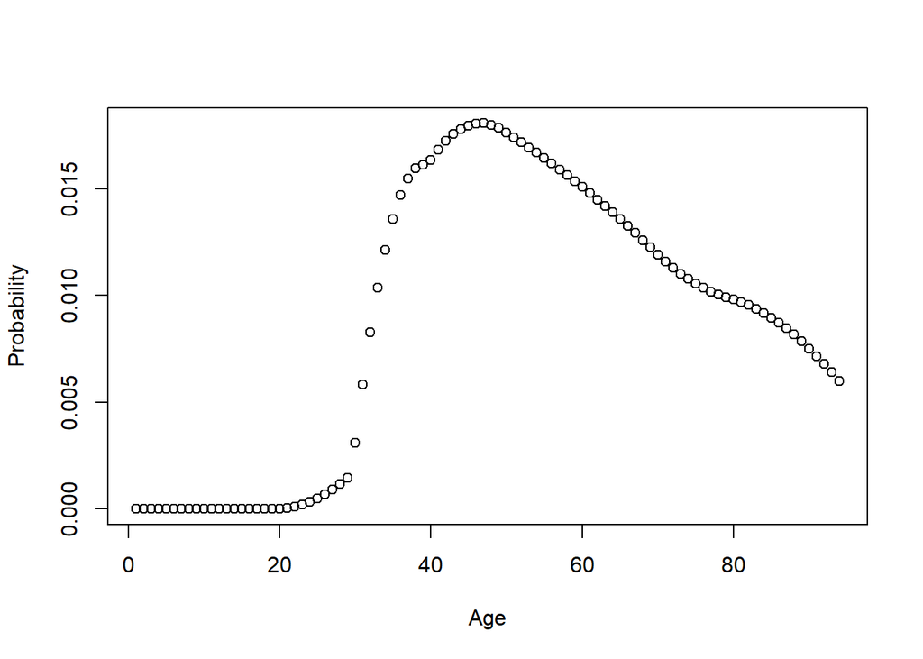

  ```r
  data1 <-readRDS("array.rds")
  data1<-data.frame(data1)
  d1<-data1[2, ] #Breast Cancer

  #Create new dataframe df with age and probability as value
  colclasses <- c("integer", "double")
  l <- lapply(colclasses, vector, length = 94)
  #Get first column of form BRCA2.All_Races.Female.1
  startidx <- grep("BRCA2.All_Races.Female.1", colnames(d1))[[1]][1]
  #After that, we need every 26*8*2=416
  for (i in 1:94) {
    idx <- startidx+(416*(i-1))
    l[[1]][i] <- i
    l[[2]][i] <- d1[1,idx]
  }
  names(l) <- c("Age","Probability")
  df <- as.data.frame(l, stringsAsFactors = FALSE)

  #Plot this new dataframe
  plot(df)
  ```

- Subset the array for the penetrances associated with `Colorectal` cancer and the `PALB2` gene for an Asian male. What is the probability that a person from this subpopulation at age 50 will develop colorectal cancer in the next 10 years given that he has tested positive for a PALB2 mutation but is otherwise disease free? *(Hint: The probability over a period of time is calculated by summing the yearly risks.)*
- **Answer**

  ```r
  #Extract row with Colorectal Cancer
  d2<-data1[4,]
  #Create new dataframe df2 with age(from 50->60) and probability as value
  colclasses <- c("integer", "double")
  l <- lapply(colclasses, vector, length = 11)
  #Get first column of form PALB2.Asian.Male.50
  startidx <- grep("PALB2.Asian.Male.50", colnames(d2))[[1]][1]
  #After that, we need every 26*8*2=416

  ### Following is my first attempt where I thought I was only to add probabilities when P for any other type of gene mutation was 0
  #  #At this point we can either loop using grep to make sure P is 0 for every other gene
  #  #Or better, use the fact that PALB2 is 19th gene in the list,and gene is the 1st column
  #  ch = 0
  #  for (i in 1:11) { #i from 1 to 11 because startidx is for age 50 and we need till 60
  #    l[[1]][i] <- 49+i
  #    ch = 0
  #    idx <- startidx+(416*(i-1))
  #
  #    #For 20->26
  #    for (k in 1:7){
  #      ch <- ch + d2[1, idx+k]
  #    }
  #    for (j in 1:18){  #For 1->18
  #      ch <- ch + d2[1, idx-j]
  #    }

  #    if (ch==0) {
  #      l[[2]][i] <- d2[1,idx]
  #    } else {
  #      l[[2]][i] <- 0
  #    }
  #  }


  for (i in 1:11) { #i from 1 to 11 because startidx is for age 50 and we need till 60
    idx <- startidx+(416*(i-1))
    l[[1]][i] <- 49+i
    l[[2]][i] <- d2[1,idx]
  }
  names(l) <- c("Age","Probability")
  df2 <- as.data.frame(l, stringsAsFactors = FALSE)
  #View(df2)
  sum(df2$Probability)
  ```

  ```
  ## [1] 0.00812721
  ```

## Family pedigrees

Read in the `.rdata` file `pedigree.rda`. Each `data.frame` represents a family. Each individual is uniquely identified by the first column called `ID`. Their sex is coded as `0` for females and `1` for males. Individuals’ mother and father are indicated in the `MotherID` and `FatherID` columns. A value of `NA` in these columns means that this person is a so-called ‘founder’ or that a certain parent is missing.

In the following exercises, you are encouraged to modularise and comment on your code.

- Write an R function(s) to count the number of unique nuclear families there are in a certain pedigree. A nuclear family is defined as the set of two parents and all of their children.
- Report the number of nuclear families for the pedigrees contained in the `.rda` file.
- **Answer**

  ```r
  numOfFam <- function(df) {

    #I create a new column "help" such that if there is an absent parent (is.na()), its value is 0. Otherwise, its value is (2^FatherID)*(3^MotherID)
    #This helps in creating a column which has a unique value for a unique pair of FatherID and MotherID. The proof lies in the fact that each number has a unique prime factorization
    a <- grep("MotherID", colnames(df))[[1]][1]
    b <- grep("FatherID", colnames(df))[[1]][1]
    n <- max(df$ID)
    namevector <- c("help")
    for (i in 1:n){
      if(is.na(df[i, a]) || is.na(df[i, b])) {
        df[i, namevector] <- 0
      } else {
        df[i, namevector] <- (2^df[i, b])*(3^df[i, a])
      }
    }

    #Now, I calculate the number of unique values in help
    base <- length(unique(df[["help"]]))

    #But, there might be 0s in "help" as well, which don't have to be counted in number of nuclear families. So, I check if there is any row in help with a 0 value and if so, I deduct 1 from the total unique values of help
    if(any(df$help==0)) {
      count<- base-1
    } else {
      count <- base
    }

    ##Show Count
    #Concatenate fam and length to signify the data.frame for which unique families have been calculated
    p<-paste(c("fam", n), collapse = "")
    #Concatenate above string and the count
    p<-paste(c(p, count), collapse = ": ")
    #Print count
    print(p, quote=FALSE)

  }

  pedData<-load("pedigree.rda")
  #Iterate over all objects of rdata file
  for (obj in pedData) {
    x <- get(obj)
    #Call the Function
    numOfFam(x)
  }
  ```

  ```
  ## [1] fam10: 4
  ## [1] fam50: 10
  ## [1] fam75: 18
  ## [1] fam100: 26
  ```